# week7

### 10.3.2

Because the model gives a result between 0 and 1, it requires setting a threshold probability to separate between “good” and “bad” answers. In this data set, they estimate that incorrectly identifying a bad customer as good, is 5 times worse than incorrectly classifying a good customer as bad. Determine a good threshold probability based on your model.

We chose a threshold of 0.5 above, now lets choose a threshold that’s makes the model more restrictive, i.e. it will reject a loan more often than approve due to the sensitivity of the use case, i.e. incorrectly identifying a bad customer as good, is 5 times worse than incorrectly classifying a good customer as bad.

```r
#Since identifying bad customer as good is  5 times worse than incorrectly classifying a good customer bad, lets look at the ROC curve
library(pROC)
roc <- roc(testing$credit_risk,testing$pred) #creates an object with all sorts of diagnostics including sensitivities and specificities
#AUC = 0.7 indicates a good model
auc(roc)
```

```
## Area under the curve: 0.7006
```

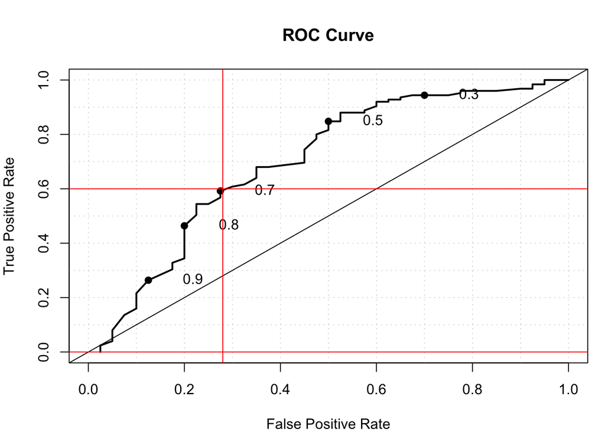

```r
#Plot the roc curve along with various threshold values
library(verification)
roc.plot(
    testing$credit_risk,
    testing$pred,
    threshold = seq(0, max(testing$pred), 0.01),
    ylab="True Positive Rate",
    xlab="False Positive Rate",
    plot.thres = c(0.3, 0.5, 0.7, 0.8, 0.9))
 abline(a=0.6,b=0, col="red")
 abline(h=0,v=0.28, col="red")
```

We want the false positive rate as low as possible while keeping the True positive rate as high as possible. From the graph above a threshold of 0.7 gets us a 60% True positive rate and 28% false positive rates. We can make the model more stricter by increasing the threshold to 0.8, which will reduce the true positives to roughly 0.5 and false positives to 0.2.

So we can say any threshold between 0.7 to 0.8 should be good for our purpose

Final confusion matrix

```r
testing$good_pred_0.7 <- ifelse(testing$pred > 0.7, 1, 0)
testing$good_pred_0.75 <- ifelse(testing$pred > 0.75, 1, 0)
testing$good_pred_0.8 <- ifelse(testing$pred > 0.8, 1, 0)

#confusion matrix
c1<-confusionMatrix(factor(testing$good_pred_0.7, levels=min(testing$credit_risk):max(testing$credit_risk)),
      factor(testing$credit_risk, levels=min(testing$credit_risk):max(testing$credit_risk)))
c2<-confusionMatrix(factor(testing$good_pred_0.75, levels=min(testing$credit_risk):max(testing$credit_risk)),
      factor(testing$credit_risk, levels=min(testing$credit_risk):max(testing$credit_risk)))
c3<-confusionMatrix(factor(testing$good_pred_0.8, levels=min(testing$credit_risk):max(testing$credit_risk)),
      factor(testing$credit_risk, levels=min(testing$credit_risk):max(testing$credit_risk)))
#Acccuracies
sum(diag(c1$table)) / sum(c1$table)
```

```
## [1] 0.6242424
```

```r
sum(diag(c2$table)) / sum(c2$table)
```

```
## [1] 0.6
```

```r
sum(diag(c3$table)) / sum(c3$table)
```

```
## [1] 0.5454545
```

As we go closer to 0.8 accuracy of the model drops (as proven by our ROC curve). Hence we conclude that a threshold of 0.7 is a fine balance between predicting good vs bad credit risks.